# GLMs in R: an introduction

Ilaria Prosdocimi

Il dataset `patents.txt` contiene informazioni raccolte dall’ufficio brevetti dell’UE su alcune caratteristiche dei brevetti, tra cui il numero di citazioni, se è stata presentata un’opposizione al brevetto, l’anno in cui il brevetto è stato depositato e l’informazione se il brevetto è nel settore bio-farmaceutico. (Il dataset è stato derivato dal dataset sulle patenti utilizzato nel libro [*Regression* di Fahrmeir et al.](https://www.uni-goettingen.de/de/regression+-+models%2c+methods+and+applications/550514.html).

```r
dat <- read.table("../data/patents.txt")
dat$biopharm <- factor(dat$biopharm)
summary(dat)
```

```
##    opposed               ncit             year      biopharm
##  Length:4809        Min.   : 0.000   Min.   :1980   0:2702
##  Class :character   1st Qu.: 0.000   1st Qu.:1989   1:2107
##  Mode  :character   Median : 1.000   Median :1992
##                     Mean   : 1.534   Mean   :1991
##                     3rd Qu.: 2.000   3rd Qu.:1994
##                     Max.   :15.000   Max.   :1997
```

# La modellazione di dati binari

Ci concentriamo ora sulla variabile `opposed`, un indicatore che ha valore “opposed” e “not-opposed”. Diamo un’occhiata alle caratteristiche della variabile:

```r
summary(dat$opposed)
```

```
##    Length     Class      Mode
##      4809 character character
```

```r
table(dat$opposed)
```

```
##
## not-opposed     opposed
##        2830        1979
```

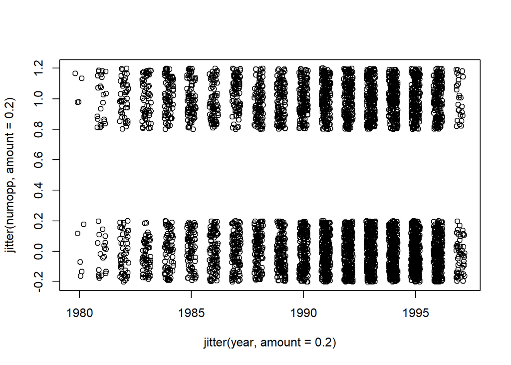

```r
# glm(opposed ~ year, data = dat, family = binomial)
# plot(opposed ~ year, data = dat)

dat$numopp <- ifelse(dat$opposed == "opposed", 1, 0)
plot(jitter(numopp, amount = 0.2) ~
       jitter(year, amount = 0.2), data = dat)
```

```r
dat$fopp <- factor(dat$opposed)
glm(numopp ~ year, data = dat, family = binomial,
    weights = rep(1, nrow(dat)))
```

```
##
## Call:  glm(formula = numopp ~ year, family = binomial, data = dat, weights = rep(1,
##     nrow(dat)))
##
## Coefficients:
## (Intercept)         year
##    88.07533     -0.04442
##
## Degrees of Freedom: 4808 Total (i.e. Null);  4807 Residual
## Null Deviance:       6515
## Residual Deviance: 6480  AIC: 6484
```

```r
fit_bin <- glm(fopp ~ year, data = dat, family = binomial)
```

```r
summary(fit_bin)
```

```
##
## Call:
## glm(formula = fopp ~ year, family = binomial, data = dat)
##
## Deviance Residuals:
##     Min       1Q   Median       3Q      Max
## -1.2337  -1.0300  -0.9603   1.3127   1.4510
##
## Coefficients:
##              Estimate Std. Error z value Pr(>|z|)
## (Intercept) 88.075330  14.806089   5.949 2.70e-09 ***
## year        -0.044416   0.007437  -5.973 2.33e-09 ***
## ---
## Signif. codes:  0 '***' 0.001 '**' 0.01 '*' 0.05 '.' 0.1 ' ' 1
##
## (Dispersion parameter for binomial family taken to be 1)
##
##     Null deviance: 6515.3  on 4808  degrees of freedom
## Residual deviance: 6479.5  on 4807  degrees of freedom
## AIC: 6483.5
##
## Number of Fisher Scoring iterations: 4
```

```r
dat$yearsSince1979 <- dat$year - 1979
fit_bin <- glm(fopp ~ yearsSince1979, data = dat, family = binomial)
summary(fit_bin)
```

```
##
## Call:
## glm(formula = fopp ~ yearsSince1979, family = binomial, data = dat)
##
## Deviance Residuals:
##     Min       1Q   Median       3Q      Max
## -1.2337  -1.0300  -0.9603   1.3127   1.4510
##
## Coefficients:
##                 Estimate Std. Error z value Pr(>|z|)
## (Intercept)     0.175950   0.093728   1.877   0.0605 .
## yearsSince1979 -0.044416   0.007437  -5.973 2.33e-09 ***
## ---
## Signif. codes:  0 '***' 0.001 '**' 0.01 '*' 0.05 '.' 0.1 ' ' 1
##
## (Dispersion parameter for binomial family taken to be 1)
##
##     Null deviance: 6515.3  on 4808  degrees of freedom
## Residual deviance: 6479.5  on 4807  degrees of freedom
## AIC: 6483.5
##
## Number of Fisher Scoring iterations: 4
```

Da dove arrivano gli standard error?

```r
X <- model.matrix(fit_bin)
lpred <- coef(fit_bin)[1] + coef(fit_bin)[2] * dat$yearsSince1979
V <- diag(exp(lpred)/((1+exp(lpred))^2) )
solve(t(X)  %*% V %*% X)
```

```
##                  (Intercept) yearsSince1979
## (Intercept)     0.0087848913  -6.618075e-04
## yearsSince1979 -0.0006618075   5.530328e-05
```

```r
vcov(fit_bin)
```

```
##                  (Intercept) yearsSince1979
## (Intercept)     0.0087848912  -6.618075e-04
## yearsSince1979 -0.0006618075   5.530328e-05
```

```r
sqrt(diag(vcov(fit_bin)))
```

```
##    (Intercept) yearsSince1979
##    0.093727750    0.007436618
```

Possiamo costruire intervalli di confidenza:

```r
confint.default(fit_bin)
```

```
##                       2.5 %      97.5 %
## (Intercept)    -0.007752872  0.35965316
## yearsSince1979 -0.058991562 -0.02984056
```

```r
fit_bin$coefficients[2] + qnorm(c(.025, 0.975)) * sqrt(diag(vcov(fit_bin)))[2]
```

```
## [1] -0.05899156 -0.02984056
```

```r
# un intervallo approssimato
```

```r
nd <- data.frame(yearsSince1979 = c(1,2,17,18))
lpred <- coef(fit_bin)[1] + coef(fit_bin)[2] * nd$yearsSince1979
lpred[2] - lpred[1]; lpred[4] - lpred[3]
```

```
## [1] -0.04441606
```

```
## [1] -0.04441606
```

```r
predict(fit_bin, newdata = nd)
```

```
##           1           2           3           4
##  0.13153408  0.08711803 -0.57912286 -0.62353892
```

```r
predict(fit_bin, newdata = nd, type = "link")
```

```
##           1           2           3           4
##  0.13153408  0.08711803 -0.57912286 -0.62353892
```

```r
(rpred <- predict(fit_bin, newdata = nd, type = "response"))
```

```
##         1         2         3         4
## 0.5328362 0.5217657 0.3591344 0.3489770
```

```r
diff(rpred)
```

```
##           2           3           4
## -0.01107045 -0.16263129 -0.01015744
```

```r
exp(lpred)/(1+exp(lpred))
```

```
## [1] 0.5328362 0.5217657 0.3591344 0.3489770
```

```r
(rpred/(1-rpred))[2]/(rpred/(1-rpred))[1]
```

```
##         2
## 0.9565559
```

```r
(rpred/(1-rpred))[4]/(rpred/(1-rpred))[3]
```

```
##         4
## 0.9565559
```

```r
exp(coef(fit_bin)[2])
```

```
## yearsSince1979
##      0.9565559
```

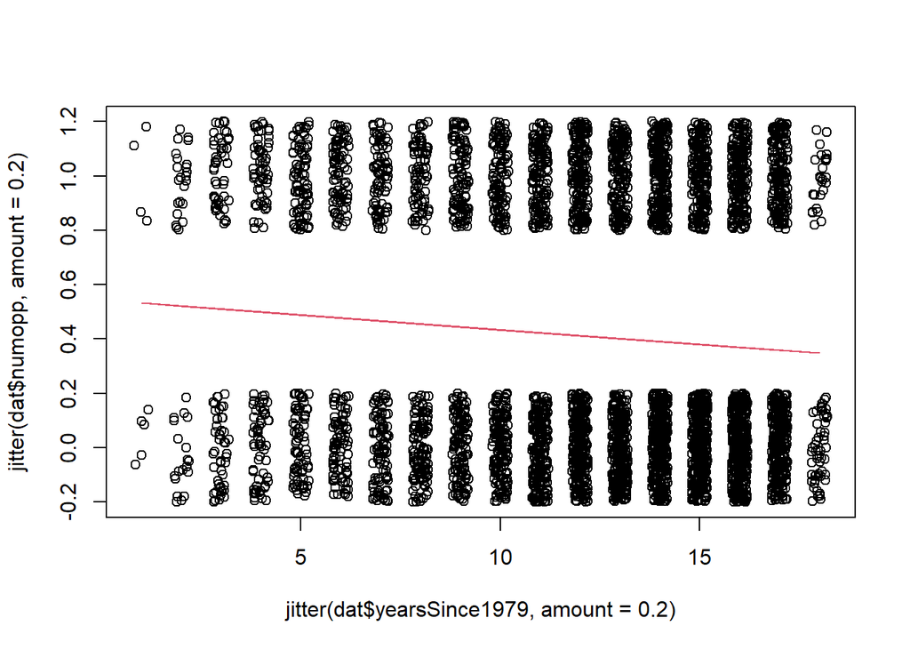

```r
plot(jitter(dat$yearsSince1979, amount = 0.2),
     jitter(dat$numopp, amount = 0.2))
lines(dat$yearsSince1979,
      predict(fit_bin, type = "response"), col = 2)
```

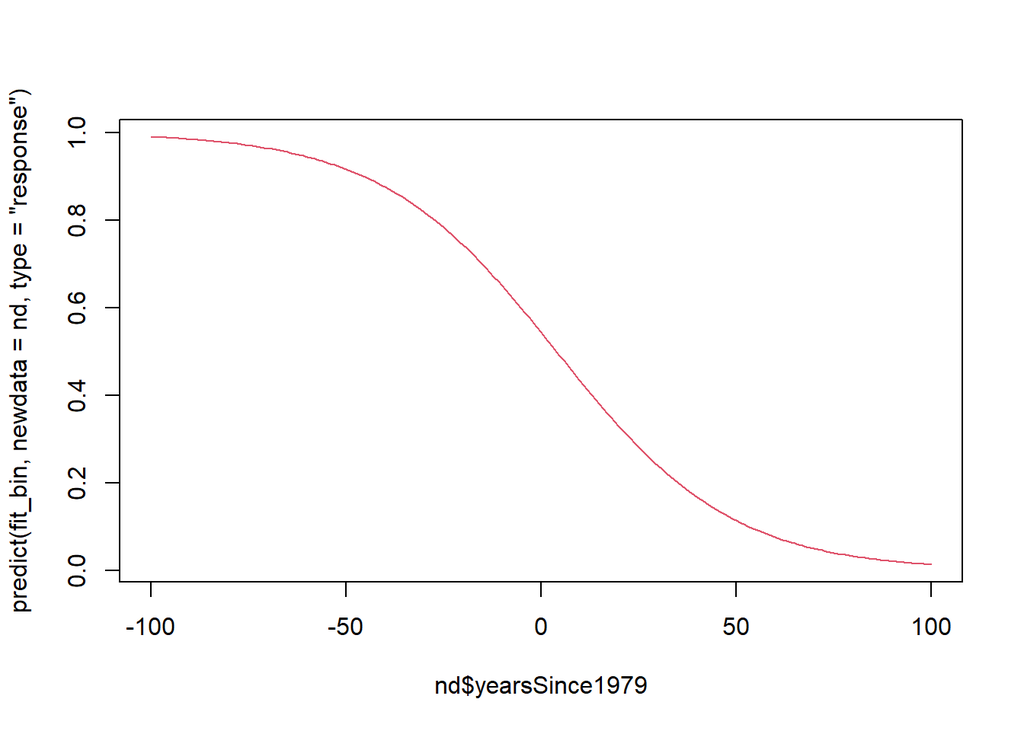

```r
nd <-data.frame(yearsSince1979 = seq(-100, 100))
plot(nd$yearsSince1979,
      predict(fit_bin, newdata = nd, type = "response"),
     type = "l", col = 2)
```

```r
fit_bin2 <- glm(fopp ~ yearsSince1979 * biopharm,
                data = dat, family = binomial)
summary(fit_bin2)
```

```
##
## Call:
## glm(formula = fopp ~ yearsSince1979 * biopharm, family = binomial,
##     data = dat)
##
## Deviance Residuals:
##     Min       1Q   Median       3Q      Max
## -1.3807  -0.9312  -0.6815   1.0576   1.8554
##
## Coefficients:
##                          Estimate Std. Error z value Pr(>|z|)
## (Intercept)               0.11956    0.12380   0.966   0.3341
## yearsSince1979           -0.09133    0.01031  -8.854  < 2e-16 ***
## biopharm1                 0.37621    0.19919   1.889   0.0589 .
## yearsSince1979:biopharm1  0.07652    0.01590   4.811  1.5e-06 ***
## ---
## Signif. codes:  0 '***' 0.001 '**' 0.01 '*' 0.05 '.' 0.1 ' ' 1
##
## (Dispersion parameter for binomial family taken to be 1)
##
##     Null deviance: 6515.3  on 4808  degrees of freedom
## Residual deviance: 6003.7  on 4805  degrees of freedom
## AIC: 6011.7
##
## Number of Fisher Scoring iterations: 4
```

# Un modello per il numero di citazioni

Ci concentriamo ora sulla variabile `ncit`, il numero di citazioni ricevute da un brevetto. Le citazioni sono in qualche modo una misura del successo di un brevetto: desideriamo verficare se i brevetti depositati recentemente hanno più successo. `ncit` è una variabile che misura dei conteggi: possiamo assumere che segua una distribuzione di Poisson. Diamo un’occhiata ai dati:

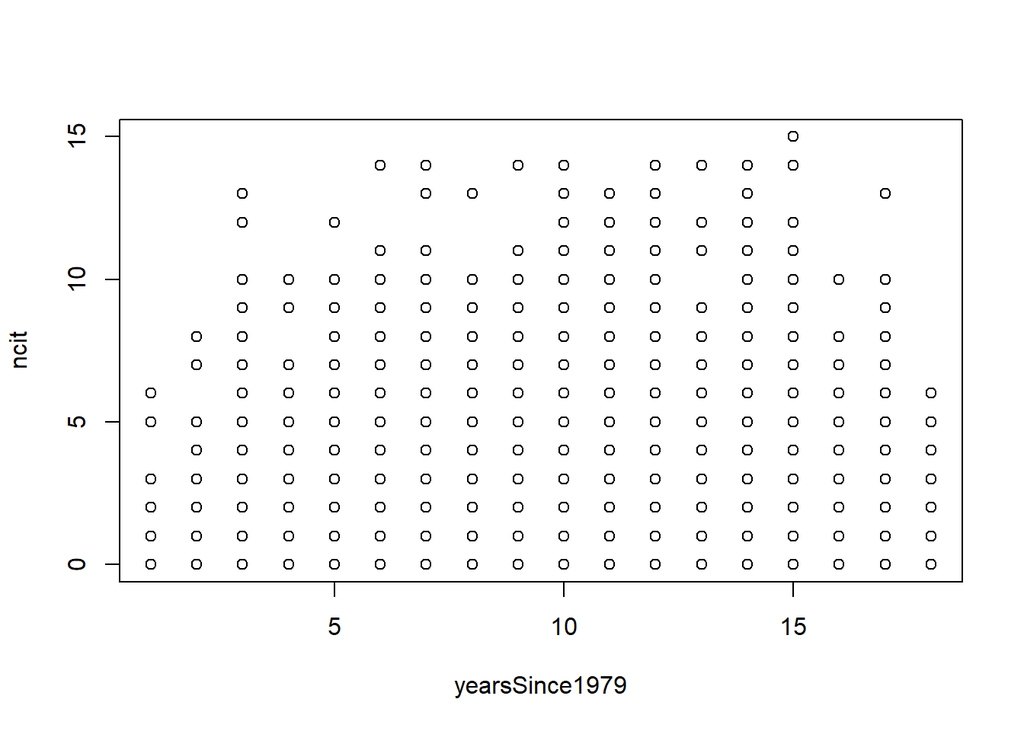

```r
# notice we already use yearSince1979
plot(ncit~yearsSince1979, data = dat)
```

Difficile sapere quanti punti ci sono in ogni combinazione - usiamo jitter

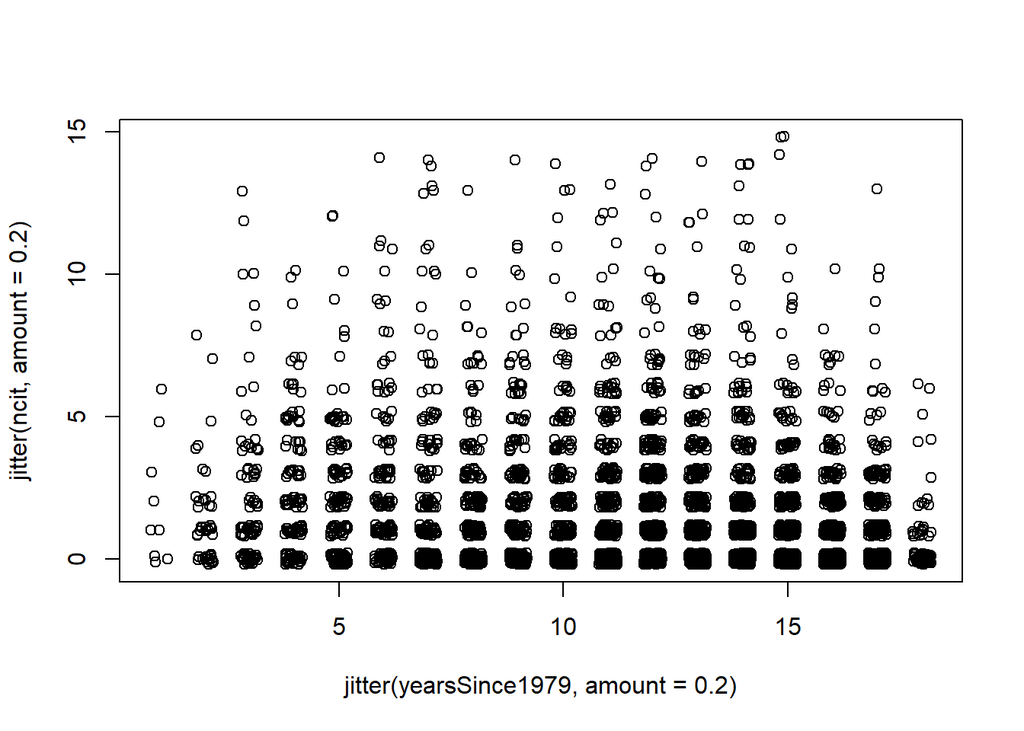

```r
plot(jitter(ncit, amount = 0.2)~jitter(yearsSince1979, amount = 0.2),
     data = dat)
```

Non un effetto chiarissimo, ma forse le citazioni di brevetti presentati di recente sono relativamente meno (hanno avuto meno tempo per essere citate). Iniziamo comunque con un modello semplice per capire come lavorare con modelli con dati di conteggio:

```r
fit_pois <- glm(ncit ~ yearsSince1979, data=dat,
                family = poisson)
summary(fit_pois)
```

```
##
## Call:
## glm(formula = ncit ~ yearsSince1979, family = poisson, data = dat)
##
## Deviance Residuals:
##     Min       1Q   Median       3Q      Max
## -2.5289  -1.6042  -0.7568   0.4942   6.9411
##
## Coefficients:
##                Estimate Std. Error z value Pr(>|z|)
## (Intercept)     1.23245    0.03202   38.49   <2e-16 ***
## yearsSince1979 -0.07003    0.00274  -25.56   <2e-16 ***
## ---
## Signif. codes:  0 '***' 0.001 '**' 0.01 '*' 0.05 '.' 0.1 ' ' 1
##
## (Dispersion parameter for poisson family taken to be 1)
##
##     Null deviance: 13359  on 4808  degrees of freedom
## Residual deviance: 12733  on 4807  degrees of freedom
## AIC: 19726
##
## Number of Fisher Scoring iterations: 6
```

```r
X <- model.matrix(fit_pois)
lpred <- coef(fit_pois)[1] + coef(fit_pois)[2] * dat$yearsSince1979
V <- diag(exp(lpred))
solve(t(X)  %*% V %*% X)
```

```
##                  (Intercept) yearsSince1979
## (Intercept)     1.025338e-03  -8.171894e-05
## yearsSince1979 -8.171894e-05   7.505507e-06
```

```r
vcov(fit_pois)
```

```
##                  (Intercept) yearsSince1979
## (Intercept)     1.025338e-03  -8.171894e-05
## yearsSince1979 -8.171894e-05   7.505507e-06
```

```r
sqrt(diag(vcov(fit_pois)))
```

```
##    (Intercept) yearsSince1979
##    0.032020899    0.002739618
```

```r
confint.default(fit_pois)
```

```
##                      2.5 %      97.5 %
## (Intercept)     1.16968845  1.29520807
## yearsSince1979 -0.07539596 -0.06465685
```

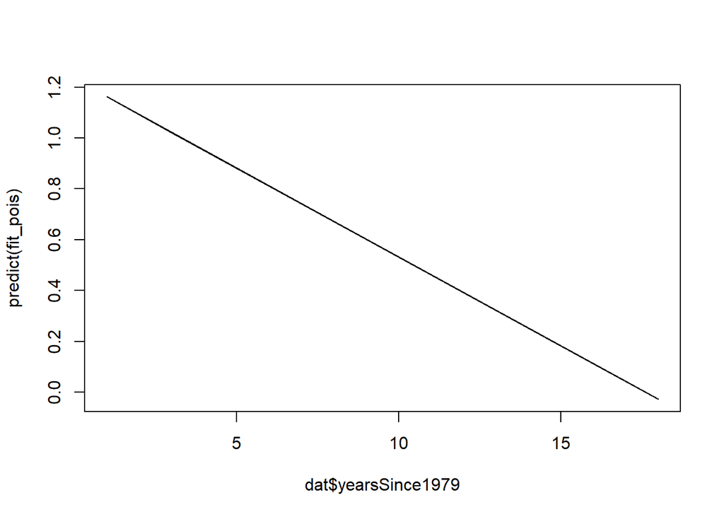

```r
plot(dat$yearsSince1979, predict(fit_pois), type = "l")
```

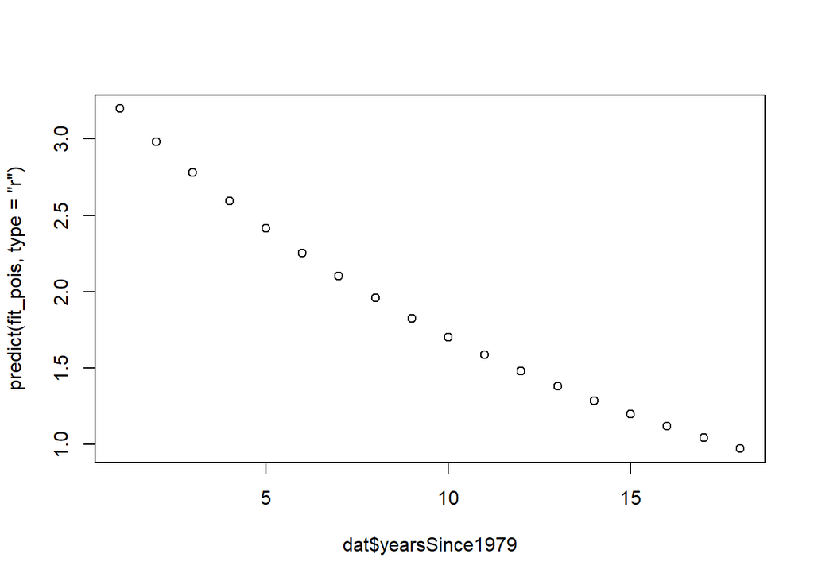

```r
plot(dat$yearsSince1979,
     predict(fit_pois, type = "r"))
```

```r
nd <- data.frame(yearsSince1979 = c(1,2,17,18))
(lpred <- predict(fit_pois, newdata = nd))
```

```
##           1           2           3           4
##  1.16242185  1.09239544  0.04199934 -0.02802707
```

```r
diff(lpred)
```

```
##           2           3           4
## -0.07002641 -1.05039611 -0.07002641
```

```r
(rpred <- predict(fit_pois, newdata = nd, type = "response"))
```

```
##        1        2        3        4
## 3.197668 2.981407 1.042894 0.972362
```

```r
rpred[2]/rpred[1]
```

```
##         2
## 0.9323692
```

```r
rpred[4]/rpred[3]
```

```
##         4
## 0.9323692
```

```r
exp(coef(fit_pois)[2])
```

```
## yearsSince1979
##      0.9323692
```

```r
fit_pois_quad <- glm(ncit ~ fopp+biopharm+
                      poly(yearsSince1979,degree = 2),
                       # yearsSince1979+I(yearsSince1979^2),
                     family = poisson,
                     data = dat)
summary(fit_pois_quad)
```

```
##
## Call:
## glm(formula = ncit ~ fopp + biopharm + poly(yearsSince1979, degree = 2),
##     family = poisson, data = dat)
##
## Deviance Residuals:
##     Min       1Q   Median       3Q      Max
## -2.4302  -1.5733  -0.7881   0.4690   7.4241
##
## Coefficients:
##                                    Estimate Std. Error z value Pr(>|z|)
## (Intercept)                         0.12306    0.01941   6.341 2.29e-10 ***
## foppopposed                         0.38109    0.02443  15.599  < 2e-16 ***
## biopharm1                           0.13651    0.02446   5.581 2.39e-08 ***
## poly(yearsSince1979, degree = 2)1 -21.72227    0.85516 -25.401  < 2e-16 ***
## poly(yearsSince1979, degree = 2)2 -12.36256    0.84054 -14.708  < 2e-16 ***
## ---
## Signif. codes:  0 '***' 0.001 '**' 0.01 '*' 0.05 '.' 0.1 ' ' 1
##
## (Dispersion parameter for poisson family taken to be 1)
##
##     Null deviance: 13359  on 4808  degrees of freedom
## Residual deviance: 12146  on 4804  degrees of freedom
## AIC: 19145
##
## Number of Fisher Scoring iterations: 6
```

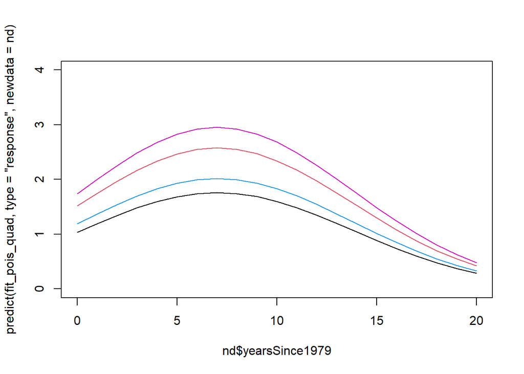

```r
nd <- data.frame(yearsSince1979 = seq(0,20),
                 biopharm = "0", fopp = "not-opposed")
plot(nd$yearsSince1979,
     predict(fit_pois_quad, type = "response", newdata = nd),
     type = "l", ylim = c(0, 4))
nd <- data.frame(yearsSince1979 = seq(0,20),
                 biopharm = "0", fopp = "opposed")
lines(nd$yearsSince1979,
      predict(fit_pois_quad, type = "response", newdata = nd),
      col = 2)
nd <- data.frame(yearsSince1979 = seq(0,20),
                 biopharm = "1", fopp = "not-opposed")
lines(nd$yearsSince1979,
      predict(fit_pois_quad, type = "response", newdata = nd),
      col = 4)
nd <- data.frame(yearsSince1979 = seq(0,20),
                 biopharm = "1", fopp = "opposed")
lines(nd$yearsSince1979,
      predict(fit_pois_quad, type = "response", newdata = nd),
      col = 6)
```

```r
anova(fit_pois, fit_pois_quad, test = "LRT")
```

```
## Analysis of Deviance Table
##
## Model 1: ncit ~ yearsSince1979
## Model 2: ncit ~ fopp + biopharm + poly(yearsSince1979, degree = 2)
##   Resid. Df Resid. Dev Df Deviance  Pr(>Chi)
## 1      4807      12733
## 2      4804      12146  3   587.31 < 2.2e-16 ***
## ---
## Signif. codes:  0 '***' 0.001 '**' 0.01 '*' 0.05 '.' 0.1 ' ' 1
```

```r
deviance(fit_pois)
```

```
## [1] 12733.34
```

```r
fit_pois$deviance
```

```
## [1] 12733.34
```

```r
fit_pois$null.deviance
```

```
## [1] 13358.79
```

```r
fit_pois_quad$deviance
```

```
## [1] 12146.03
```

```r
fit_pois_quad$null.deviance
```

```
## [1] 13358.79
```

```r
(fit_pois$deviance - fit_pois_quad$deviance)
```

```
## [1] 587.3149
```

```r
pchisq((fit_pois$deviance - fit_pois_quad$deviance),
       df = 3, lower.tail = FALSE)
```

```
## [1] 5.666469e-127
```

```r
2*(logLik(fit_pois_quad) - logLik(fit_pois))
```

```
## 'log Lik.' 587.3149 (df=5)
```

## modellazione di proporzioni

```r
byYear <- data.frame(
  npatent = tapply(dat$numopp, dat$year, length),
  numopposed = tapply(dat$numopp, dat$year, sum),
  year = tapply(dat$year, dat$year, unique))
byYear$notOpposed <- byYear$npatent - byYear$numopposed
byYear$propOpposed <- byYear$numopposed/byYear$npatent
summary(glm(propOpposed ~ year, data = byYear, family = binomial,
            weights = npatent))
```

```
##
## Call:
## glm(formula = propOpposed ~ year, family = binomial, data = byYear,
##     weights = npatent)
##
## Deviance Residuals:
##     Min       1Q   Median       3Q      Max
## -1.0404  -0.4326  -0.1138   0.2669   1.0923
##
## Coefficients:
##              Estimate Std. Error z value Pr(>|z|)
## (Intercept) 88.075330  14.806089   5.949 2.70e-09 ***
## year        -0.044416   0.007437  -5.973 2.33e-09 ***
## ---
## Signif. codes:  0 '***' 0.001 '**' 0.01 '*' 0.05 '.' 0.1 ' ' 1
##
## (Dispersion parameter for binomial family taken to be 1)
##
##     Null deviance: 42.0829  on 17  degrees of freedom
## Residual deviance:  6.3097  on 16  degrees of freedom
## AIC: 112.16
##
## Number of Fisher Scoring iterations: 3
```

```r
summary(glm(cbind(numopposed, notOpposed) ~ year, data = byYear, family = binomial))
```

```
##
## Call:
## glm(formula = cbind(numopposed, notOpposed) ~ year, family = binomial,
##     data = byYear)
##
## Deviance Residuals:
##     Min       1Q   Median       3Q      Max
## -1.0404  -0.4326  -0.1138   0.2669   1.0923
##
## Coefficients:
##              Estimate Std. Error z value Pr(>|z|)
## (Intercept) 88.075330  14.806089   5.949 2.70e-09 ***
## year        -0.044416   0.007437  -5.973 2.33e-09 ***
## ---
## Signif. codes:  0 '***' 0.001 '**' 0.01 '*' 0.05 '.' 0.1 ' ' 1
##
## (Dispersion parameter for binomial family taken to be 1)
##
##     Null deviance: 42.0829  on 17  degrees of freedom
## Residual deviance:  6.3097  on 16  degrees of freedom
## AIC: 112.16
##
## Number of Fisher Scoring iterations: 3
```

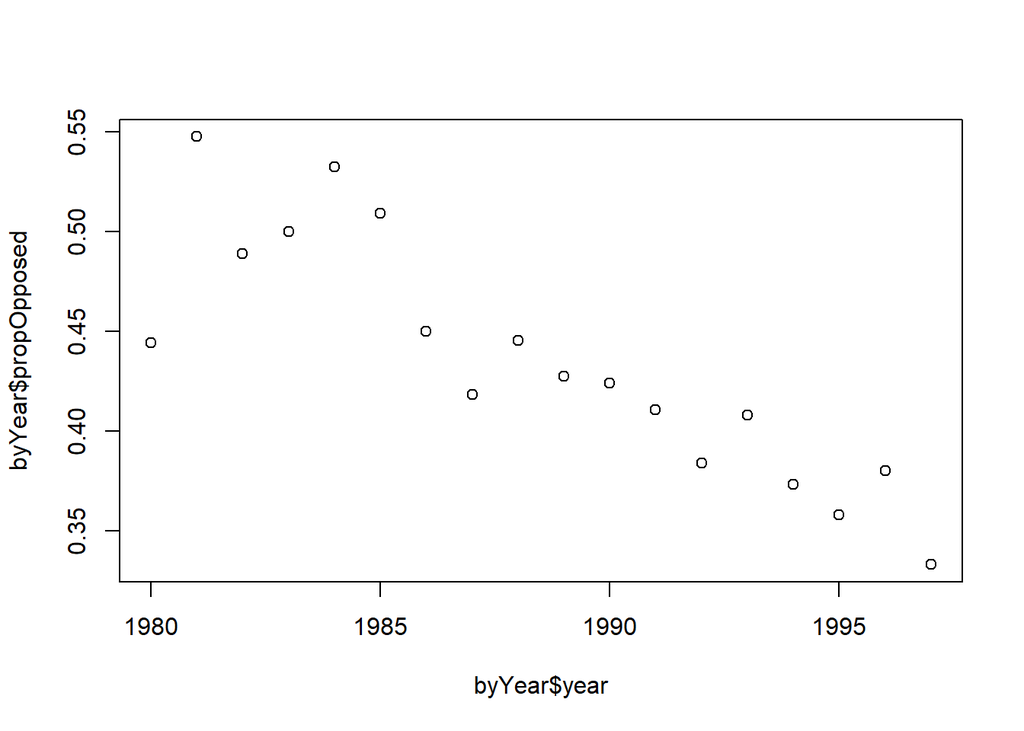

```r
plot(byYear$year, byYear$propOpposed)
```

# verifica della teoria tramite simulazione

In un GLM dobbiamo fare due scelte:

- distribuzione
- funzione legame
- (i predittori)

Simuliamo dati da una Binomiale con funzione legame logit e un predittore:

```r
# TO FIX
n <- 6000
set.seed(12)
x <- sort(runif(n, 0,1))
beta_true <- c(-5,10)
plot(x, beta_true[1]+beta_true[2]*x)
plot(x, exp(beta_true[1]+beta_true[2]*x)/(1+exp(beta_true[1]+beta_true[2]*x)))
lines(x, binomial()$linkinv(beta_true[1]+beta_true[2]*x))
plot(x, y_sim)

beta_sim <- NULL
for(i in 1:500){
  y_sim <- rbinom(n,5,binomial()$linkinv(beta_true[1]+beta_true[2]*x))
  beta_sim <- rbind(beta_sim,
                    coef(glm(cbind(y_sim, 5-y_sim) ~ x, family = binomial)))
}
colMeans(beta_sim)
apply(beta_sim, 2, sd)
cov(beta_sim)
X <- cbind(rep(1, n), x)
V <- diag(exp(beta_true[1]+beta_true[2]*x)/((1+exp(beta_true[1]+beta_true[2]*x))^2))
solve((t(X) %*% V %*% X))/5
par(mfrow=c(1,2))
hist(beta_sim[,1])
hist(beta_sim[,2])
```